# Polished Lab Notebook No. 1

Christopher Ackerman-Avila

3/22/2021

# Opportunity Zones

*In 2017, the Tax Cuts and Jobs Act was signed and created Opportnity Zones as a means to spur investments in economically disadvantaged Census tracts across the country. Although the mechanism has been subject to much critique, it has altered the landscape of investing in low-income communities. Below is a demographic analysis of Opportunity Zones in places and demographics of interest.*

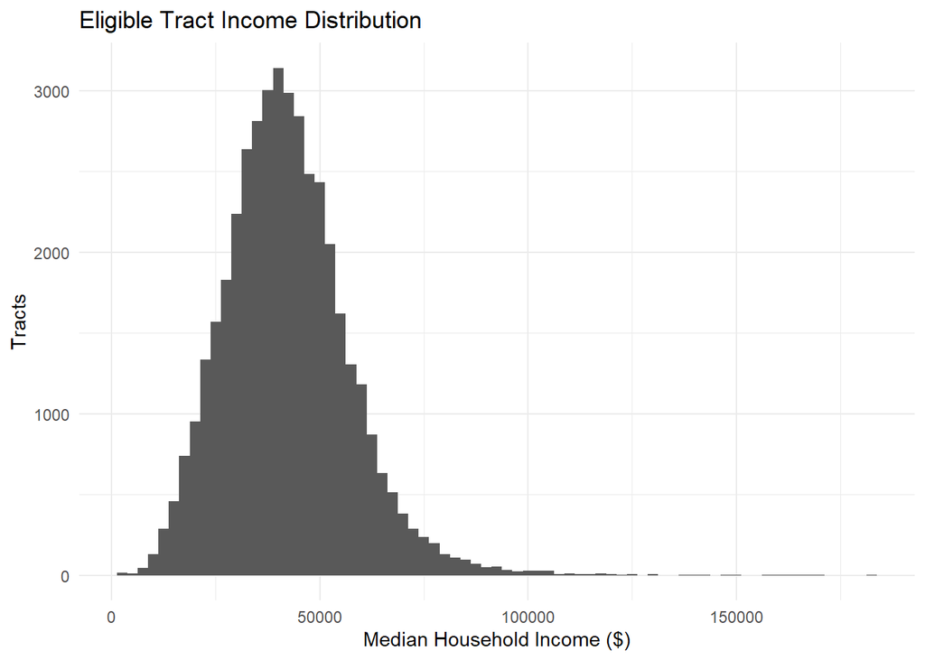

```
## # A tibble: 3 x 5
## # Groups:   Metro [2]
##   Metro Micro Income Poverty Hispanic
##   <dbl> <dbl>  <dbl>   <dbl>    <dbl>
## 1     1    NA 32787.   0.334   0.347
## 2    NA     1 34470.   0.280   0.153
## 3    NA    NA 36368.   0.236   0.0960
```

# Median Household Income

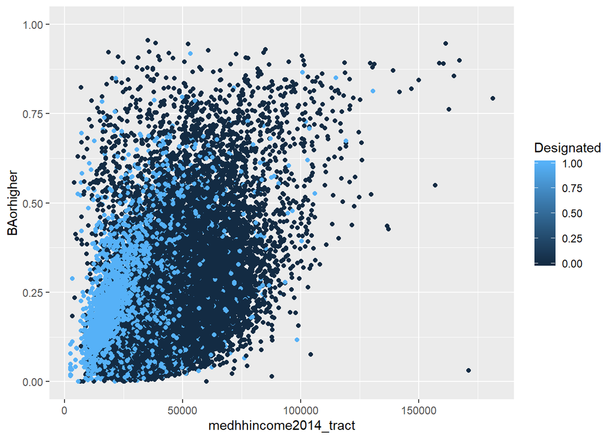

# Education

*There is also a positive relationship between median household income, educational attainment, and Opportunity Zone designation. Non-designated tracts (in dark blue) have higher median household incomes compared to tracts with a designation.*

```r
ozs %>%
  group_by(Designated, Metro) %>%
  summarise(College = mean(BAorhigher, na.rm=TRUE))
```

```
## # A tibble: 4 x 3
## # Groups:   Designated [2]
##   Designated Metro College
##        <dbl> <dbl>   <dbl>
## 1          0     1   0.222
## 2          0    NA   0.167
## 3          1     1   0.180
## 4          1    NA   0.161
```

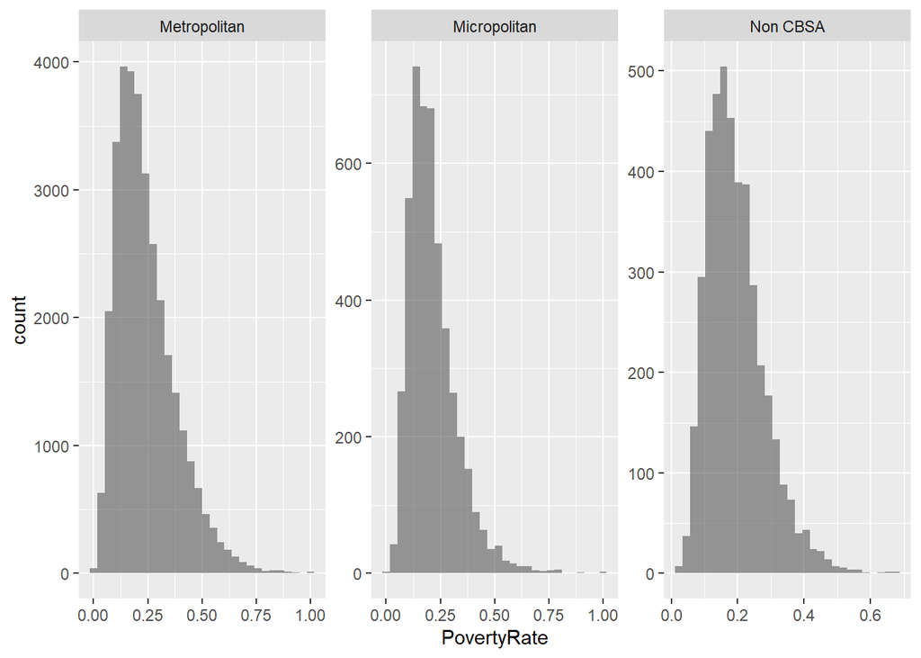

```r
ozs %>% mutate(Metro = ifelse(Metro == 1, "Metropolitan", NA),
               Micro = ifelse(Micro == 1, "Micropolitan", NA),
               NoCBSAType = ifelse(NoCBSAType == 1, "Non CBSA", NA),
               Metro_Type = case_when(Metro == "Metropolitan" ~ "Metropolitan",
                                      Micro == "Micropolitan" ~ "Micropolitan",
                                      NoCBSAType == "Non CBSA" ~ "Non CBSA")) %>%
  ggplot(aes(x=PovertyRate, fill=Designated))+geom_histogram(alpha=.6)+
  facet_wrap(~Metro_Type, scales = "free")
```

```r
ozs %>%
  filter(Designated == 1) %>%
  group_by(state) %>%
  summarise(
    Metropolitan = mean(PovertyRate[Metro == 1], na.rm=TRUE),
    Micropolitan = mean(PovertyRate[Micro == 1], na.rm=TRUE),
    Non_CBSA = mean(PovertyRate[NoCBSAType == 1], na.rm=TRUE))
```

```
## # A tibble: 56 x 4
##    state                Metropolitan Micropolitan Non_CBSA
##  * <chr>                       <dbl>        <dbl>    <dbl>
##  1 Alabama                     0.347        0.282    0.275
##  2 Alaska                      0.156      NaN        0.178
##  3 American Samoa            NaN          NaN      NaN
##  4 Arizona                     0.319        0.311    0.239
##  5 Arkansas                    0.334        0.287    0.262
##  6 California                  0.332        0.311    0.209
##  7 Colorado                    0.245        0.169    0.201
##  8 Connecticut                 0.284        0.319  NaN
##  9 Delaware                    0.262      NaN      NaN
## 10 District of Columbia        0.322      NaN      NaN
## # ... with 46 more rows
```

# Metro vs Micro

*Not only can we see that there are many more designated tracts in metropolitan areas, but it is also evident that there is higher levels of poverty in Metros, too. This varies between states, however. Different states have varying levels of Metropolitan and Micropolitan levels of poverty. In some places, metros fare better and vice versa.*

```r
ozs %>%
  group_by(Designated) %>%
  summarise(
    Tracts = n(),
    White = mean(pctwhitealone, na.rm=TRUE),
    Black = mean(pctblackalone, na.rm=TRUE),
    Hispanic = mean(pctHispanic, na.rm=TRUE),
    AAPI = mean(pctAAPIalone, na.rm=TRUE))
```

```
## # A tibble: 2 x 6
##   Designated Tracts White Black Hispanic   AAPI
## *      <dbl>  <int> <dbl> <dbl>    <dbl>  <dbl>
## 1          0  33414 0.554 0.172    0.200 0.0404
## 2          1   8762 0.396 0.240    0.299 0.0292
```

# People of Color

*Designated Opportunity Zone tracts have higher proportion of people of color than non-designated tracts. Designated tracts see their share of White people decrease from 55% to 39.5% while their share of Back and Latino people increase from 17% to 24% and 20% to 29%, respectively. This pattern demonstrates that communities of color are set to see more investment with the Opportunity Zones program.But this also demonstrates that communities of color are more socioeconomically disadvantaged than White communities.*

```r
ozs %>%
  select(state, pctHispanic, pctwhitealone, pctblackalone, Micro) %>%
  group_by(state) %>%
  filter(Micro == "1", state %in% c("California", "Idaho", "Kansas", "Arizona", "Alabama", "Mississippi")) %>%
  summarise(
    Rural_White = mean(pctwhitealone[Micro == 1], na.rm=TRUE),
    Rural_Latinos = mean(pctHispanic[Micro == 1], na.rm=TRUE),
    Rural_Black = mean(pctblackalone[Micro == 1]))
```

```
## # A tibble: 6 x 4
##   state       Rural_White Rural_Latinos Rural_Black
##   <chr>             <dbl>         <dbl>       <dbl>
## 1 Alabama           0.653        0.0480     0.270
## 2 Arizona           0.410        0.279      0.00753
## 3 California        0.714        0.168      0.0165
## 4 Idaho             0.773        0.171      0.00641
## 5 Kansas            0.714        0.187      0.0404
## 6 Mississippi       0.472        0.0209     0.491
```

# The South, West, and Heartland

```r
mean(ozs$PovertyRate[ozs$pctHispanic>.2 & ozs$Designated == 1], na.rm=TRUE)
```

```
## [1] 0.3474449
```

```r
mean(ozs$PovertyRate[ozs$Designated == 1], na.rm=TRUE)
```

```
## [1] 0.3175123
```

```r
mean(ozs$PovertyRate[ozs$pctHispanic>.5 & ozs$Designated == 1], na.rm=TRUE)
```

```
## [1] 0.3871986
```

# Latino Poverty

*The general poverty rate for designated Census tracts is 31.75%. However, when factoring in Census tracts with over 20% Hispanic population, that number increases further to 34.74%. Census tracts with above average Latino populations (the nationwide Latino population is 19%) have higher levels of poverty. Even worse, for designated Census tracts with Latino populations over 50%, the number jumps to a staggering 38.7% poverty rate.*

*Studies show that Latinos are increasingly turning away from expensive coastal and gateway cities such as Los Angeles or New York and heading towards affordable rural areas in the South and Midwest. Although these places may be more affordable, they lead to more isolated livelihoods for newcomers as they may find it difficult to recieve the services and assistance resettlement requires. As Latinos turn to settling in Kansas, Idaho, the Dakotas, and other states, they may or may not struggle to increase their social mobility.*